# TP1-Result

*Aprender una técnica no es un fin en si mismo, simplemente indica por donde hay que empezar*  
**Proverbio Japonés**

*Material curado y organizado por el Prof. Dr. Hernán D. Merlino*  
*NLP Versión 1.0 - 2022 Q2*

**Auto NLP**

**_____________________________________________________________**

```python
from platform import python_version

# En produccion sacar, solo se incluye a modo de informacion
print('Pyton version: {}'.format(python_version()))
```

```
Pyton version: 3.8.13
```

```python
!jupyter --version
```

```
Selected Jupyter core packages...
IPython          : 8.6.0
ipykernel        : 6.17.1
ipywidgets       : 8.0.2
jupyter_client   : 7.4.4
jupyter_core     : 5.0.0
jupyter_server   : 1.23.1
jupyterlab       : 3.5.0
nbclient         : 0.7.0
nbconvert        : 7.2.4
nbformat         : 5.7.0
notebook         : 6.5.2
qtconsole        : not installed
traitlets        : 5.5.0
```

```python
import warnings
warnings.filterwarnings("ignore")
```

```python
# En produccion sacar, solo se incluye a modo de informacion
import pycaret
print('Pycaret version:  %s' % pycaret.__version__)

from pycaret.nlp import *
```

```
Pycaret version:  2.3.10
```

```python
import pandas as pd

df = pd.read_csv("datasets/Datafiniti_Hotel_Reviews.csv")
df.head()
```

|  | id | dateAdded | dateUpdated | address | categories | primaryCategories | city | country | keys | latitude | ... | reviews.dateSeen | reviews.rating | reviews.sourceURLs | reviews.text | reviews.title | reviews.userCity | reviews.userProvince | reviews.username | sourceURLs | websites |
| --- | --- | --- | --- | --- | --- | --- | --- | --- | --- | --- | --- | --- | --- | --- | --- | --- | --- | --- | --- | --- | --- |
| 0 | AVwc252WIN2L1WUfpqLP | 2016-10-30T21:42:42Z | 2018-09-10T21:06:27Z | 5921 Valencia Cir | Hotels,Hotels and motels,Hotel and motel reser... | Accommodation & Food Services | Rancho Santa Fe | US | us/ca/ranchosantafe/5921valenciacir/359754519 | 32.990959 | ... | 2016-08-03T00:00:00Z,2016-07-26T00:00:00Z,2016... | 5.0 | https://www.hotels.com/hotel/125419/reviews%20/ | Our experience at Rancho Valencia was absolute... | Best romantic vacation ever!!!! | NaN | NaN | Paula | http://www.hotels.com/ho125419/%25252525253Flo... | http://www.ranchovalencia.com |
| 1 | AVwc252WIN2L1WUfpqLP | 2016-10-30T21:42:42Z | 2018-09-10T21:06:27Z | 5921 Valencia Cir | Hotels,Hotels and motels,Hotel and motel reser... | Accommodation & Food Services | Rancho Santa Fe | US | us/ca/ranchosantafe/5921valenciacir/359754519 | 32.990959 | ... | 2016-08-02T00:00:00Z,2016-08-26T00:00:00Z,2016... | 5.0 | https://www.hotels.com/hotel/125419/reviews%20/ | Amazing place. Everyone was extremely warm and... | Sweet sweet serenity | NaN | NaN | D | http://www.hotels.com/ho125419/%25252525253Flo... | http://www.ranchovalencia.com |
| 2 | AVwc252WIN2L1WUfpqLP | 2016-10-30T21:42:42Z | 2018-09-10T21:06:27Z | 5921 Valencia Cir | Hotels,Hotels and motels,Hotel and motel reser... | Accommodation & Food Services | Rancho Santa Fe | US | us/ca/ranchosantafe/5921valenciacir/359754519 | 32.990959 | ... | 2016-11-15T00:00:00Z,2016-08-23T00:00:00Z,2016... | 5.0 | https://www.hotels.com/hotel/125419/reviews%20/ | We booked a 3 night stay at Rancho Valencia to... | Amazing Property and Experience | NaN | NaN | Ron | http://www.hotels.com/ho125419/%25252525253Flo... | http://www.ranchovalencia.com |
| 3 | AVwdOclqIN2L1WUfti38 | 2015-11-28T19:19:35Z | 2018-09-10T21:06:16Z | 7520 Teague Rd | Hotels,Hotels and motels,Travel agencies and b... | Accommodation & Food Services | Hanover | US | us/md/hanover/7520teaguerd/-2043779672 | 39.155929 | ... | 2016-05-21T00:00:00Z,2016-07-31T00:00:00Z | 2.0 | https://www.tripadvisor.com/Hotel_Review-g4118... | Currently in bed writing this for the past hr ... | Never again...beware, if you want sleep. | Richmond | VA | jaeem2016 | http://www.yellowbook.com/profile/aloft-arunde... | http://www.starwoodhotels.com/alofthotels/prop... |
| 4 | AVwdOclqIN2L1WUfti38 | 2015-11-28T19:19:35Z | 2018-09-10T21:06:16Z | 7520 Teague Rd | Hotels,Hotels and motels,Travel agencies and b... | Accommodation & Food Services | Hanover | US | us/md/hanover/7520teaguerd/-2043779672 | 39.155929 | ... | 2016-07-31T00:00:00Z | 5.0 | https://www.tripadvisor.com/Hotel_Review-g4118... | I live in Md and the Aloft is my Home away fro... | ALWAYS GREAT STAY... | Laurel | MD | MamaNiaOne | http://www.yellowbook.com/profile/aloft-arunde... | http://www.starwoodhotels.com/alofthotels/prop... |

5 rows × 25 columns

```python
df.columns
```

```
Index(['id', 'dateAdded', 'dateUpdated', 'address', 'categories',
       'primaryCategories', 'city', 'country', 'keys', 'latitude', 'longitude',
       'name', 'postalCode', 'province', 'reviews.date', 'reviews.dateSeen',
       'reviews.rating', 'reviews.sourceURLs', 'reviews.text', 'reviews.title',
       'reviews.userCity', 'reviews.userProvince', 'reviews.username',
       'sourceURLs', 'websites'],
      dtype='object')
```

```python
df.shape
```

```
(10000, 25)
```

```python
df = df[['categories','city','name','reviews.rating','reviews.text','reviews.title','reviews.userCity']]
```

```python
df.columns
```

```
Index(['categories', 'city', 'name', 'reviews.rating', 'reviews.text',
       'reviews.title', 'reviews.userCity'],
      dtype='object')
```

```python
df.shape
```

```
(10000, 7)
```

```python
df =df.rename(columns={
    'reviews.rating': "rating",
    'reviews.text': "text",
    'reviews.title': "title",
    'reviews.userCity': "userCity"

})
```

```python
df.columns
```

```
Index(['categories', 'city', 'name', 'rating', 'text', 'title', 'userCity'], dtype='object')
```

```python
df.dtypes
```

```
categories     object
city           object
name           object
rating        float64
text           object
title          object
userCity       object
dtype: object
```

```python
#df = df[df.rating < 3]
```

```python
df.shape
```

```
(10000, 7)
```

```python
# Elegimos la muestra (analizar entre 1500 y 3000)
#data = df.sample(1500, random_state=786).reset_index(drop=True)
data = df.sample(1500, random_state=786).reset_index(drop=True)
data.shape
```

```
(1500, 7)
```

```python
stop_words= ['make','room', 'hotel', 'stay', 'good', 'bad', 'und', 'der', 'great', 'go', 'lot', 'staff', 'get', 'would', 'night']

exp_nlp101 = setup(data = data, target = 'text', session_id = 1213, verbose=True, custom_stopwords=stop_words)
```

| Description | Value |
| --- | --- |
| session_id | 1213 |
| Documents | 1500 |
| Vocab Size | 3815 |
| Custom Stopwords | True |

**Listado de modelos**

```python
models()
```

| ID | Name | Reference |
| --- | --- | --- |
| lda | Latent Dirichlet Allocation | gensim/models/ldamodel |
| lsi | Latent Semantic Indexing | gensim/models/lsimodel |
| hdp | Hierarchical Dirichlet Process | gensim/models/hdpmodel |
| rp | Random Projections | gensim/models/rpmodel |
| nmf | Non-Negative Matrix Factorization | sklearn.decomposition.NMF |

```python
lda = create_model(model='lda', num_topics=3, verbose=True)
```

```python
print(lda)
```

```
LdaModel(num_terms=3815, num_topics=3, decay=0.5, chunksize=100)
```

**Asignar resultado**

```python
lda_results = assign_model(lda)
```

**Visualización**

```python
plot_model(model=lda, plot='frequency')
```

[interactive chart not shown]

```python
plot_model(model=lda, plot = 'bigram')
```

[interactive chart not shown]

```python
plot_model(model=lda, plot = 'trigram')
```

[interactive chart not shown]

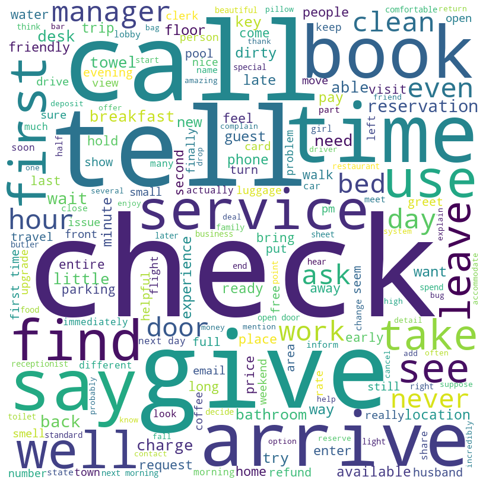

```python
plot_model(model=lda, plot='wordcloud')
```

**Análisis**

```python
plot_model(model=lda, plot = 'topic_distribution')
```

[interactive chart not shown]

```python
plot_model(model=lda, plot = 'frequency', topic_num = 'Topic 0')
```

[interactive chart not shown]

```python
plot_model(model=lda, plot = 'frequency', topic_num = 'Topic 2')
```

[interactive chart not shown]

```python
plot_model(model=lda, plot = 'bigram', topic_num = 'Topic 0')
```

[interactive chart not shown]

```python
plot_model(model=lda, plot = 'bigram', topic_num = 'Topic 2')
```

[interactive chart not shown]

```python
plot_model(model=lda, plot = 'frequency', topic_num = 'Topic 1')
```

[interactive chart not shown]

```python
plot_model(model=lda, plot = 'bigram', topic_num = 'Topic 1')
```

[interactive chart not shown]

```python
print(lda_results[lda_results['Dominant_Topic'] == 'Topic 0']['rating'].mean())
print(lda_results[lda_results['Dominant_Topic'] == 'Topic 1']['rating'].mean())
print(lda_results[lda_results['Dominant_Topic'] == 'Topic 2']['rating'].mean())
```

```
2.9818518518518515
4.1637048192771084
2.6486486486486487
```

Durante el proceso de NLP se realizaron pruebas con los siguientes grupos de valores:

- Cantidad de tópicos: [2,3,4,5]
- Tamaño de la muestra: [1000, 1200, 1500, 2000, 3000]
- Stop words: ['make','room', 'hotel', 'stay', 'good', 'bad', 'und', 'der', 'great', 'go', 'lot', 'staff', 'get', 'would', 'night']

En cada iteración se fueron agregando stopwords, así como modificando los valores mencionados para buscar tópicos a los que se les pueda asignar algún sentido, así como una buena distribución de las filas en los mismos.

Se encontró el mejor resultado, el más factible de análisis, usando los valores:

- Cantidad de tópicos: 3
- Tamaño de la muestra: 1500
- Stop words: ['make','room', 'hotel', 'stay', 'good', 'bad', 'und', 'der', 'great', 'go', 'lot', 'staff', 'get', 'would', 'night']

Se le asigna el siguiente significado a cada tópico obtenido: Tópico 1: Contiene principalmente las reseñas positivas. Esto se ve claramente al observar los gráficos de frecuencia de palabras y bigramas, como así también la nube de palabras. Podemos encontrar palabras como clean, comfortable, nice, helpful, friendly, etc. Además, si observamos el promedio del rating es de más de 4/5.

Tópico 0: Este tópico contiene reseñas mayormente negativas, pero que usan palabras constructivas y se refieren a cosas que se podrían mejorar.

Topico 2: Aquí se concentran las reseñas definitivamente negativas, con un vocabulario más fuerte que en el tópico anterior, lo cual indicaría que quien escribió la reseña lo hizo con enojo. Se observan palabras como stain, terrible, dirty, disgusting, cigarette, critter y cockroach.

Analizando los promedios de ratings de cada topico, vemos que el Topico 1 es claramente el que tiene reviews buenas, mientras que los otros representan malas. Sin embargo, el Topico 0 se aproxima al rating medio de 3, y el Topico 2 tiene valores mas negativos. El modelo bien seprara 2 tipos de reviews "malas" como las criticas constructivas y los descargos por enojo.

**Visualización Automática**

```python
evaluate_model(model=lda)
```

```
interactive(children=(ToggleButtons(description='Plot Type:', icons=('',), options=(('Frequency Plot', 'freque…
```

**_____________________________________________________________**

**Salvar el modelo**

```python
save_model(lda, 'AutoNLP_PyCaret_KivaDataSet')
```

**_____________________________________________________________**

**_____________________________________________________________**